# Most harmfull weather event types in the U.S. in 1950 - 2011

Nikita Sokolov

17/11/2014

## Synopsis

In this report we explore the U.S. National Oceanic and Atmospheric Administration’s (NOAA) storm database in order to answer the following questions:

1. Across the United States, which types of events are most harmful with respect to population health?
2. Across the United States, which types of events have the greatest economic consequences?

This database tracks characteristics of major storms and weather events in the United States from 1950 till 2011, including estimates of any fatalities, injuries, and property damage. So, to answer those questions we will summarise this estimates by event types.

## Data Processing

At first we need to download data and load it into R environment. Notice that we can load it straight without unpacking.

```r
if (!file.exists("stormdata.bz2")){
        download.file(url = "https://d396qusza40orc.cloudfront.net/repdata%2Fdata%2FStormData.csv.bz2", destfile = "stormdata.bz2", method = "curl")
}

stormdata <- read.table(bzfile("stormdata.bz2"), header = TRUE, sep=',', na.strings = "", stringsAsFactors = FALSE)
```

It seems that entries in database are made by hand by diffrent people. So we need to somehow clean the data to get it into more appropriate condition.

Because of entries in EVTYPE column have mistakes or similar event types are named differently, we have too much of them. For example there’re such types: “Coastal Flood”, “COASTALFLOOD”, " COASTAL FLOOD“,”coastal flooding“,”Coastal Flooding“,”COASTAL FLOODING“. Obviously they all are the same type, but R will consider them as different. So we need such entries to be of one type. But that’s not the only case, we can go further. In general there is not much difference between”Coastal flood" and “River Flood”. I think very strong specification is not suitable for our purposes. So I decided to combine several similar types into more common types.

So, I saved all the types in separate file:

```r
initTypes <- levels(stormdata$EVTYPE)
save (initTypes, file = "evtypes.txt")
```

Then I created another file for correction, you can check it at [my GitHub repo](https://github.com/fakedup/RR_PA2/blob/master/edited_evtypes.csv).

I load that file and change EVTYPE according to it.

```r
evtypesCorrection <- read.csv("edited_evtypes.csv", stringsAsFactors = FALSE)
for (i in (1:length(evtypesCorrection[,1]))){
        stormdata$EVTYPE[stormdata$EVTYPE==evtypesCorrection$wrong[i]] <- evtypesCorrection$right[i]
}
```

So we’ve got not so much types:

```r
stormdata$EVTYPE <- as.factor(stormdata$EVTYPE)
head (stormdata$EVTYPE)
```

```
## [1] TORNADO TORNADO TORNADO TORNADO TORNADO TORNADO
## 186 Levels:  ? ABNORMALLY DRY ABNORMALLY WET ... WINTER WEATHER
```

Now we need to get property damage values to common units. Let’s take a look.

```r
table (stormdata$PROPDMGEXP)
```

```
##
##      -      ?      +      0      1      2      3      4      5      6
##      1      8      5    216     25     13      4      4     28      4
##      7      8      B      h      H      K      m      M
##      5      1     40      1      6 424665      7  11330
```

Some values are not in appropriate format, as described at [instruction](https://d396qusza40orc.cloudfront.net/repdata%2Fpeer2_doc%2Fpd01016005curr.pdf). We will ignore them and set to 0.

```r
costSign <- data.frame(sign = c('K','M','B'),val = c(10**3,10**6,10**9))

stormdata$PROPDMGEXP[!stormdata$PROPDMGEXP %in% costSign$sign] <- 0
stormdata$CROPDMGEXP[!stormdata$CROPDMGEXP %in% costSign$sign] <- 0
```

Right signs we replace with their values.

```r
for (i in (1:3)){
        stormdata$PROPDMGEXP[stormdata$PROPDMGEXP == costSign$sign[i]] <- costSign$val[i]
        stormdata$CROPDMGEXP[stormdata$CROPDMGEXP == costSign$sign[i]] <- costSign$val[i]

}
```

Now we can get all values in the same units - US dollars.

```r
stormdata$PROPDMGEXP <- as.numeric(stormdata$PROPDMGEXP)
stormdata$PROPDMG <- stormdata$PROPDMG*stormdata$PROPDMGEXP

stormdata$CROPDMGEXP <- as.numeric(stormdata$CROPDMGEXP)
stormdata$CROPDMG <- stormdata$CROPDMG*stormdata$CROPDMGEXP

stormdata <- subset(stormdata, select=-c(CROPDMGEXP, PROPDMGEXP))
```

There is an outlier in the data. Actually I’ve looked for all the considered variables, but outlier is only one, so because of restriction of the number of plots in this assesment, I don’t show other cases.

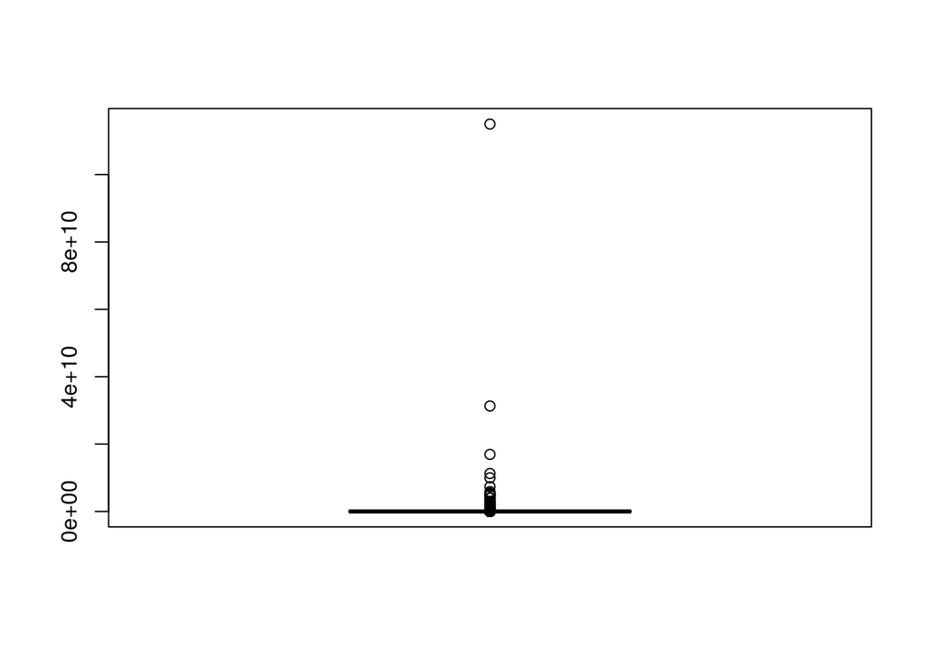

```r
boxplot(stormdata$PROPDMG[stormdata$PROPDMG != 0])
```

This damage value seems to be erroneous. Fortunately there is a remark at this string:

```r
stormdata$REMARKS[stormdata$PROPDMG==max(stormdata$PROPDMG)]
```

```
## [1] "Major flooding continued into the early hours of January 1st, before the Napa River finally fell below flood stage and the water receeded. Flooding was severe in Downtown Napa from the Napa Creek and the City and Parks Department was hit with $6 million in damage alone. The City of Napa had …
```

So I decided to change outlier value by the sum of values mentioned in the remark:

```r
stormdata$PROPDMG[stormdata$PROPDMG==max(stormdata$PROPDMG)] <- 76000000
```

## Results

Followed results are just first examination. My chosen approach is to look for the total caused harms without respect to averages and frequencies of different event types.

For the first question we can see aggregated sums of injuries and fatalities.

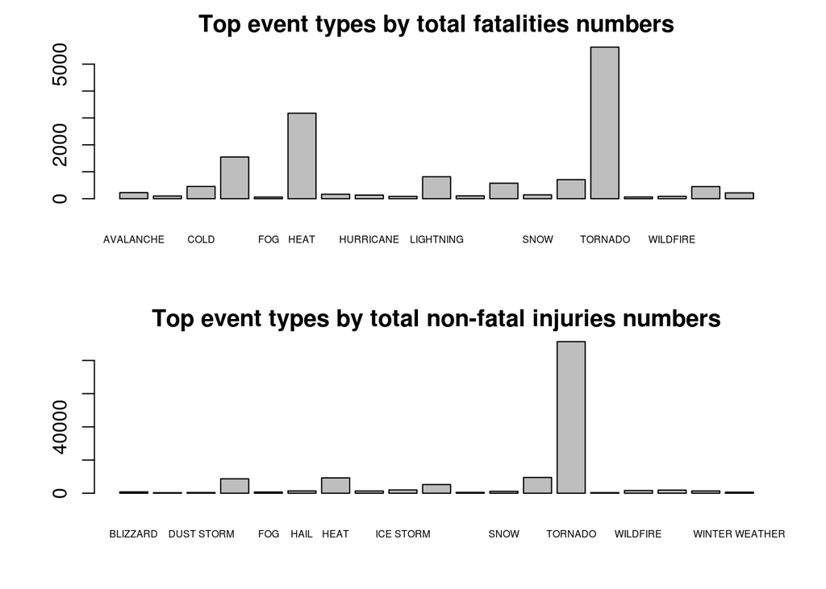

```r
par(mar = c(4,4,2,2))
par (mfrow = c(2,1))

fatalities <- aggregate (FATALITIES~EVTYPE, stormdata, sum)
fatalities <- fatalities[fatalities$FATALITIES > quantile(fatalities$FATALITIES, probs = 0.9), ]

injuries <- aggregate (INJURIES~EVTYPE, stormdata, sum)
injuries <- injuries[injuries$INJURIES > quantile(injuries$INJURIES, probs = 0.9), ]

with (fatalities, {
        barplot (FATALITIES, names.arg = EVTYPE, las = 0, cex.names=0.5, main = "Top event types by total fatalities numbers")
})
with (injuries, {
        barplot (INJURIES, names.arg = EVTYPE, las = 0, cex.names=0.5, main = "Top event types by total non-fatal injuries numbers")
})
```

According to resulting plot it is clear, that most harmfull event type at fatal and non-fatal injuries is tornado.

For the seccond question we can aggregate the sums of property and crop damages.

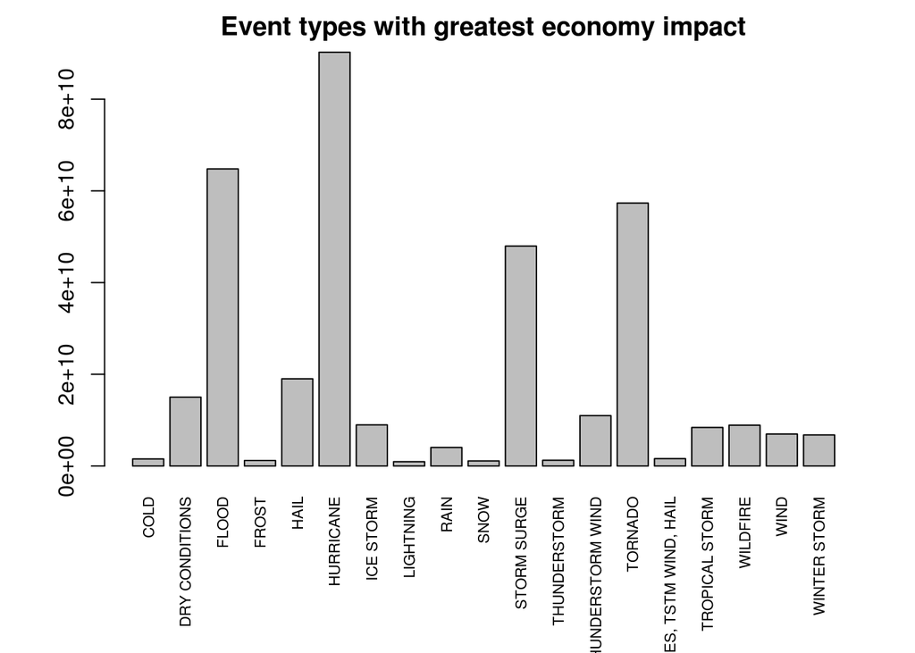

```r
par(mar = c(7,4,2,2))
par (mfrow = c(1,1))

damageCost <- aggregate (cbind (PROPDMG, CROPDMG)~EVTYPE, stormdata, sum)
damageCost <- damageCost[(damageCost$PROPDMG + damageCost$CROPDMG > quantile (damageCost$PROPDMG + damageCost$CROPDMG, probs = 0.9)),]

with (damageCost, {
        barplot (PROPDMG+CROPDMG, names.arg = EVTYPE, las = 3, cex.names=0.7, main = "Event types with greatest economy impact")
})
```

So, as for economics the worst weather event type is hurricane.